# implication_tree_gen_selective

```python
import pandas as pd
from nltk.corpus import wordnet as wn
import numpy as np
```

```python
vec_length = 600
epochs = 10

# vecs_df = pd.read_csv("/var/tmp/vectors/1b%sd_vectors_e%s_sample1e4_nonbin" % (vec_length, epochs),
#                       skiprows=[0], header=None, sep=" ")

vecs_df = pd.read_csv("/var/tmp/xstefan3/vectors/1b600d_vectors_e10_sample1e4_nonbin",
                      skiprows=[0], header=None, sep=" ")

vecs_df = vecs_df.set_index(0)
vecs_df = vecs_df.drop(columns=[vecs_df.columns[-1]])
vecs_df = vecs_df.replace(vecs_df.values.max(), 1)
vecs_df = vecs_df.replace(vecs_df.values.min(), 0)
# retype to minimal range int to save space
vecs_df = vecs_df.astype('bool')
vecs_df.head(20)
```

| 0 | 1 | 2 | 3 | 4 | 5 | 6 | 7 | 8 | 9 | 10 | ... | 591 | 592 | 593 | 594 | 595 | 596 | 597 | 598 | 599 | 600 |
| --- | --- | --- | --- | --- | --- | --- | --- | --- | --- | --- | --- | --- | --- | --- | --- | --- | --- | --- | --- | --- | --- |
| </s> | True | True | False | False | False | True | True | False | False | True | ... | True | False | False | False | True | True | False | False | False | False |
| the | False | False | True | True | False | False | True | False | True | True | ... | False | True | True | True | False | True | True | True | False | True |
| of | False | False | True | False | True | False | False | False | False | False | ... | False | True | False | True | True | True | False | True | True | True |
| and | False | False | True | True | False | True | True | False | False | False | ... | False | True | True | True | False | False | True | True | False | True |
| one | False | False | False | True | False | False | True | False | True | False | ... | True | True | False | False | True | False | False | True | False | True |
| in | False | True | True | True | True | False | True | False | True | False | ... | True | True | False | True | True | False | False | True | True | True |
| a | False | False | False | False | True | False | True | False | True | False | ... | False | True | False | False | True | False | False | True | True | True |
| to | True | False | False | True | False | False | False | False | True | True | ... | False | False | True | False | False | True | False | True | True | True |
| zero | False | False | False | True | False | False | False | False | True | True | ... | True | False | False | True | True | False | False | True | False | False |
| nine | False | False | False | True | True | True | False | False | True | True | ... | True | True | False | True | True | True | True | True | False | True |
| two | False | False | True | True | False | False | False | False | True | True | ... | True | True | False | True | True | False | False | True | False | True |
| is | True | True | True | True | True | False | True | False | True | True | ... | False | True | True | False | True | True | True | False | False | False |
| as | False | False | True | True | True | False | True | True | True | False | ... | False | True | True | False | False | True | True | True | False | True |
| eight | False | False | False | True | True | True | False | False | False | False | ... | True | True | False | True | True | True | False | True | True | False |
| for | True | False | True | False | True | True | True | False | True | True | ... | False | True | True | True | True | False | True | True | True | True |
| s | False | True | True | True | True | True | True | False | True | True | ... | True | True | False | False | True | False | True | True | False | True |
| five | False | True | False | True | False | False | False | False | True | True | ... | True | False | False | True | True | True | False | True | True | False |
| three | False | False | False | True | False | True | False | False | True | False | ... | True | False | False | True | True | False | False | True | True | True |
| was | True | False | False | False | True | True | True | False | True | False | ... | False | True | True | True | False | False | True | False | False | True |
| by | True | True | True | False | True | False | True | True | False | False | ... | False | False | True | False | True | True | True | True | False | True |

20 rows × 600 columns

```python
vecs_df.mean(axis=0).sort_values().reset_index()[0].plot(grid=True)
```

[output not shown]

## Feature clustering and voting for configuration

1. create memoization table for 4 configurations of each pair - distance matrix
2. select k-ples of features for full bruteforce evaluation - k-ples must contain each feature at least, say, 100 times
3. vote for the evaluation of the feature based in its configuration in the best valued results in the k-ples
4. construct the configuration based on voting results - check the voting's preference ratios
5. alter the original space based on the reconstructed configuration

### 1: create memoization table for 4 configurations of each pair - distance matrix

### Implications collection

For each pair of features (x, y), compute a ratio of the pairs of bits (x_i, y_i), where x_i => y_i.

Do this for each mapping in {x<>y, inverse(x)<>y, x<>inverse(y), inverse(x)<>inverse(y)} and select a mapping of x from (x, inverse(x)) so, that a maximum sum of implication probability with other bits is reached.

```python
def feature_dist(x, y):
    pos_pairs = sum((~x) | y)
    all_pairs = len(y)
    return float(pos_pairs) / all_pairs
```

```python
%%timeit i=100

feature_dist(pd.Series([1, 0, 1, 0]), pd.Series([1, 1, 0, 0]))
```

```
1.09 ms ± 7.56 µs per loop (mean ± std. dev. of 7 runs, 1000 loops each)
```

```python
%%timeit i=100

feature_dist(pd.Series([1, 0, 1, 0]), pd.Series([1, 1, 0, 0]))
```

```
1.41 ms ± 11.9 µs per loop (mean ± std. dev. of 7 runs, 1000 loops each)
```

```python
def all_combs_dist(x, y):
    return [feature_dist(x, y), feature_dist(~x, y), feature_dist(x, ~y), feature_dist(~x, ~y)]
```

```python
no_words = len(vecs_df.index)
no_features = int(1e2)

widx = np.random.choice(np.arange(len(vecs_df.index)), no_words, replace=False)
# fidx = np.random.choice(vecs_df.columns, no_features, replace=False)
fidx = vecs_df.columns

dists = vecs_df[fidx].iloc[widx].apply(lambda col1: vecs_df[fidx].iloc[widx]
                                       .apply(lambda col2: all_combs_dist(col1, col2), axis=0), axis=0)
```

```python
dists.to_pickle("dists_impl_simple.pkl")
```

```python
dists.applymap(lambda x2: [round(x1, 4) for x1 in x2]).head(8)
```

|  | 1 | 2 | 3 | 4 | 5 | 6 | 7 | 8 | 9 | 10 | ... | 591 | 592 | 593 | 594 | 595 | 596 | 597 | 598 | 599 | 600 |
| --- | --- | --- | --- | --- | --- | --- | --- | --- | --- | --- | --- | --- | --- | --- | --- | --- | --- | --- | --- | --- | --- |
| 1 | [1.0, 0.344, 0.656, 1.0] | [0.703, 0.641, 0.8425, 0.8134] | [0.5927, 0.7513, 0.789, 0.867] | [0.6466, 0.6974, 0.8097, 0.8463] | [0.7029, 0.6411, 0.837, 0.819] | [0.7069, 0.6371, 0.8451, 0.8108] | [0.6503, 0.6937, 0.7981, 0.8579] | [0.7157, 0.6284, 0.8475, 0.8085] | [0.6202, 0.7238, 0.7979, 0.8581] | [0.6991, 0.6449, 0.8368, 0.8191] | ... | [0.7159, 0.6281, 0.8644, 0.7916] | [0.6332, 0.7109, 0.817, 0.839] | [0.6593, 0.6847, 0.8024, 0.8536] | [0.6912, 0.6528, 0.8384, 0.8176] | [0.6204, 0.7236, 0.8172, 0.8388] | [0.6992, 0.6448, 0.8349, 0.8211] | [0.6924, 0.6517, 0.8367, 0.8193] | [0.5959, 0.7481, 0.8051, 0.8509] | [0.871, 0.473, 0.9191, 0.7369] | [0.6168, 0.7272, 0.8093, 0.8467] |
| 2 | [0.8134, 0.641, 0.8425, 0.703] | [1.0, 0.4544, 0.5456, 1.0] | [0.6626, 0.7919, 0.7192, 0.8264] | [0.6957, 0.7587, 0.7606, 0.785] | [0.7429, 0.7115, 0.797, 0.7486] | [0.76, 0.6944, 0.792, 0.7535] | [0.6976, 0.7568, 0.7507, 0.7948] | [0.7589, 0.6956, 0.8043, 0.7413] | [0.6792, 0.7752, 0.7388, 0.8067] | [0.751, 0.7034, 0.7849, 0.7606] | ... | [0.7737, 0.6807, 0.8066, 0.739] | [0.6933, 0.7612, 0.7569, 0.7887] | [0.6989, 0.7556, 0.7628, 0.7828] | [0.7412, 0.7132, 0.7884, 0.7572] | [0.6943, 0.7601, 0.7433, 0.8023] | [0.7437, 0.7107, 0.7903, 0.7552] | [0.7438, 0.7107, 0.7853, 0.7603] | [0.6715, 0.7829, 0.7295, 0.816] | [0.8833, 0.5711, 0.9068, 0.6387] | [0.6844, 0.77, 0.7417, 0.8039] |
| 3 | [0.867, 0.7513, 0.789, 0.5927] | [0.8264, 0.7919, 0.7192, 0.6626] | [1.0, 0.6183, 0.3817, 1.0] | [0.7964, 0.8219, 0.6599, 0.7218] | [0.8148, 0.8034, 0.7251, 0.6566] | [0.8165, 0.8018, 0.7356, 0.6461] | [0.7791, 0.8392, 0.6693, 0.7124] | [0.8349, 0.7834, 0.7283, 0.6534] | [0.7848, 0.8335, 0.6333, 0.7484] | [0.8135, 0.8048, 0.7224, 0.6593] | ... | [0.843, 0.7752, 0.7373, 0.6444] | [0.7955, 0.8228, 0.6547, 0.727] | [0.7946, 0.8236, 0.667, 0.7147] | [0.8221, 0.7962, 0.7076, 0.6742] | [0.7835, 0.8348, 0.6541, 0.7276] | [0.8287, 0.7896, 0.7054, 0.6763] | [0.8127, 0.8055, 0.7163, 0.6654] | [0.7784, 0.8399, 0.6227, 0.759] | [0.9201, 0.6982, 0.8701, 0.5116] | [0.7885, 0.8298, 0.6376, 0.7441] |
| 4 | [0.8463, 0.6974, 0.8097, 0.6466] | [0.785, 0.7587, 0.7606, 0.6957] | [0.7218, 0.8219, 0.6599, 0.7964] | [1.0, 0.5437, 0.4563, 1.0] | [0.7859, 0.7578, 0.754, 0.7023] | [0.7985, 0.7452, 0.7535, 0.7028] | [0.75, 0.7937, 0.6984, 0.7579] | [0.7934, 0.7503, 0.7698, 0.6865] | [0.7431, 0.8006, 0.675, 0.7813] | [0.7912, 0.7525, 0.7447, 0.7116] | ... | [0.8059, 0.7378, 0.7745, 0.6818] | [0.7446, 0.7991, 0.7056, 0.7507] | [0.7565, 0.7872, 0.7051, 0.7512] | [0.7838, 0.7599, 0.7458, 0.7105] | [0.7412, 0.8025, 0.6964, 0.7599] | [0.7906, 0.7531, 0.7434, 0.7129] | [0.7937, 0.75, 0.7354, 0.7209] | [0.7244, 0.8193, 0.6766, 0.7796] | [0.9015, 0.6422, 0.8886, 0.5677] | [0.737, 0.8067, 0.6891, 0.7672] |
| 5 | [0.819, 0.6411, 0.837, 0.7029] | [0.7486, 0.7115, 0.797, 0.7429] | [0.6566, 0.8034, 0.7251, 0.8148] | [0.7023, 0.7578, 0.754, 0.7859] | [1.0, 0.4601, 0.5399, 1.0] | [0.7569, 0.7031, 0.7951, 0.7448] | [0.7096, 0.7505, 0.7388, 0.8012] | [0.7692, 0.6909, 0.794, 0.7459] | [0.687, 0.7731, 0.731, 0.8089] | [0.7466, 0.7135, 0.7894, 0.7506] | ... | [0.7717, 0.6884, 0.8086, 0.7313] | [0.7091, 0.7509, 0.741, 0.7989] | [0.7176, 0.7425, 0.7441, 0.7958] | [0.7438, 0.7162, 0.7858, 0.7541] | [0.6986, 0.7615, 0.739, 0.8009] | [0.7479, 0.7122, 0.7862, 0.7538] | [0.7474, 0.7127, 0.7816, 0.7583] | [0.6826, 0.7775, 0.7184, 0.8215] | [0.8836, 0.5764, 0.9065, 0.6334] | [0.6927, 0.7674, 0.7334, 0.8065] |
| 6 | [0.8108, 0.6371, 0.8451, 0.7069] | [0.7535, 0.6944, 0.792, 0.76] | [0.6461, 0.8018, 0.7356, 0.8165] | [0.7028, 0.7452, 0.7535, 0.7985] | [0.7448, 0.7031, 0.7951, 0.7569] | [1.0, 0.448, 0.552, 1.0] | [0.6985, 0.7494, 0.7499, 0.8022] | [0.7591, 0.6888, 0.8041, 0.748] | [0.6718, 0.7761, 0.7463, 0.8058] | [0.7493, 0.6987, 0.7867, 0.7654] | ... | [0.7806, 0.6673, 0.7997, 0.7523] | [0.696, 0.752, 0.7542, 0.7979] | [0.6952, 0.7528, 0.7665, 0.7856] | [0.7376, 0.7103, 0.792, 0.76] | [0.6953, 0.7527, 0.7423, 0.8097] | [0.7441, 0.7038, 0.7899, 0.7621] | [0.7416, 0.7064, 0.7875, 0.7646] | [0.6614, 0.7865, 0.7396, 0.8125] | [0.884, 0.564, 0.9062, 0.6459] | [0.6775, 0.7704, 0.7486, 0.8035] |
| 7 | [0.8579, 0.6937, 0.7981, 0.6503] | [0.7948, 0.7568, 0.7507, 0.6976] | [0.7124, 0.8392, 0.6693, 0.7791] | [0.7579, 0.7937, 0.6984, 0.75] | [0.8012, 0.7505, 0.7388, 0.7096] | [0.8022, 0.7494, 0.7499, 0.6985] | [1.0, 0.5516, 0.4484, 1.0] | [0.8038, 0.7478, 0.7594, 0.689] | [0.7463, 0.8053, 0.6717, 0.7766] | [0.8007, 0.7509, 0.7352, 0.7132] | ... | [0.8047, 0.7469, 0.7756, 0.6728] | [0.75, 0.8017, 0.7002, 0.7482] | [0.7655, 0.7861, 0.6962, 0.7522] | [0.792, 0.7596, 0.7376, 0.7108] | [0.7525, 0.7991, 0.6851, 0.7633] | [0.7784, 0.7732, 0.7556, 0.6928] | [0.7946, 0.757, 0.7345, 0.7139] | [0.7313, 0.8203, 0.6697, 0.7787] | [0.901, 0.6506, 0.8891, 0.5593] | [0.7422, 0.8094, 0.6839, 0.7645] |
| 8 | [0.8085, 0.6284, 0.8475, 0.7157] | [0.7413, 0.6956, 0.8043, 0.7589] | [0.6534, 0.7834, 0.7283, 0.8349] | [0.6865, 0.7503, 0.7698, 0.7934] | [0.7459, 0.6909, 0.794, 0.7692] | [0.748, 0.6888, 0.8041, 0.7591] | [0.689, 0.7478, 0.7594, 0.8038] | [1.0, 0.4368, 0.5632, 1.0] | [0.6729, 0.7639, 0.7451, 0.818] | [0.7334, 0.7034, 0.8025, 0.7606] | ... | [0.7715, 0.6653, 0.8088, 0.7543] | [0.6922, 0.7446, 0.7579, 0.8053] | [0.6947, 0.7421, 0.767, 0.7962] | [0.7355, 0.7013, 0.7941, 0.7691] | [0.6827, 0.7541, 0.7549, 0.8083] | [0.7309, 0.7059, 0.8031, 0.7601] | [0.7301, 0.7067, 0.799, 0.7642] | [0.6656, 0.7713, 0.7355, 0.8277] | [0.8839, 0.553, 0.9063, 0.6569] | [0.6765, 0.7604, 0.7496, 0.8135] |

8 rows × 600 columns

### 2. select k-ples of features for full bruteforce evaluation - k-ples must contain each feature at least, say, 100 times

```python
def feature_dist_mem(x_i, y_i, is_x_neg, is_y_neg):
    dist_idx = 0
    if is_x_neg:
        dist_idx += 1
    if is_y_neg:
        dist_idx += 2
    # pure magic this
    return dists[x_i][y_i][dist_idx]
```

```python
feature_dist(~vecs_df[2], ~vecs_df[1])
```

```
0.813440686762705
```

```python
feature_dist_mem(2, 1, 1, 1)
```

[output not shown]

```python
%%timeit i=100
feature_dist(~vecs_df[2], ~vecs_df[1])
```

```
6.79 ms ± 381 µs per loop (mean ± std. dev. of 7 runs, 100 loops each)
```

```python
%%timeit i=100
feature_dist_mem(2, 1, 1, 1)
```

```
50.3 µs ± 200 ns per loop (mean ± std. dev. of 7 runs, 10000 loops each)
```

```python
def configure_features(features_idx, config):
#     print("Config: %s" % str(config))
    vecs_df_confged = [~vecs_df[fidx] if cfg==1 else vecs_df[fidx] for cfg, fidx in zip(config, features_idx)]
    return pd.concat(vecs_df_confged, axis=1)
```

```python
def valuate_features(vecs_df_subset):
    dists2 = vecs_df_subset.apply(lambda f1: vecs_df_subset.apply(lambda f2: feature_dist(f1, f2), axis=0), axis=0)
    out = dists2.values.sum() / np.prod(dists2.shape)
#     print("Config val: %s" % out)
    return out
```

```python
def valuate_features_mem(features_idx, config):
    dists2 = np.array([feature_dist_mem(fidx1, fidx2, cfg1, cfg2) for fidx1, cfg1 in zip(features_idx, config)
                                                                  for fidx2, cfg2 in zip(features_idx, config)])
    out = dists2.sum() / np.prod(dists2.shape)
#     print("Config val: %s" % out)
    return out
```

### 3. vote for the evaluation of the feature based in its configuration in the best valued results in the k-ples

```python
import itertools

def compute_top_config(features_idx, mem=True):
    configs = list(itertools.product([0, 1], repeat=len(features_idx)))
    if mem:
        configs_vals = np.array([valuate_features_mem(features_idx, cfg) for cfg in configs])
    else:
        configs_vals = np.array([valuate_features(configure_features(features_idx, cfg)) for cfg in configs])
    best_config = configs[configs_vals.argmax()]
    print("Features %s best config: %s val %s" % (list(features_idx), list(best_config), configs_vals.max()))
    return best_config
```

```python
fids = [23, 123, 45, 321]

compute_top_config(fids)
```

```
Features [23, 123, 45, 321] best config: [0, 1, 0, 0] val 0.8166625170077569
```

```
(0, 1, 0, 0)
```

```python
# test - swapped variables, consistent result
fids = [45, 23, 321, 123]

compute_top_config(fids)
```

```
Features [45, 23, 321, 123] best config: [0, 0, 0, 1] val 0.816662517007757
```

```
(0, 0, 0, 1)
```

```python
%%time

fids = np.random.choice(vecs_df.columns, 6, replace=False)
compute_top_config(fids)
print("done")
```

```
Features [212, 123, 426, 110, 76, 441] best config: [0, 0, 1, 0, 1, 0] val 0.796994010464154
done
CPU times: user 145 ms, sys: 1e+03 µs, total: 146 ms
Wall time: 152 ms
```

```python
%%time

fids = np.random.choice(vecs_df.columns, 6, replace=False)
compute_top_config(fids, mem=False)
print("done")
```

```
Features [307, 578, 62, 239, 375, 541] best config: [0, 0, 0, 1, 1, 0] val 0.8037667213720292
done
CPU times: user 17.7 s, sys: 3 ms, total: 17.7 s
Wall time: 17.7 s
```

```python
features_top_config = pd.DataFrame()
for tested_fid in np.random.choice(vecs_df.columns, 101, replace=False):
    best_configs = [compute_top_config([tested_fid] + list(np.random.choice(vecs_df.columns, 4, replace=False)))
                    for i in range(100)]
    features_top_config[tested_fid] = pd.Series(best_configs).apply(lambda x: x[0])
```

```
Features [123, 239, 56, 594, 111] best config: [0, 1, 1, 1, 1] val 0.8025579666437559
Features [123, 20, 155, 355, 389] best config: [0, 0, 1, 1, 0] val 0.8045913228878819
Features [123, 494, 411, 99, 304] best config: [0, 0, 1, 0, 1] val 0.8051389375938056
Features [123, 302, 167, 82, 216] best config: [1, 1, 1, 0, 0] val 0.8057617371056657
Features [123, 597, 437, 33, 548] best config: [0, 0, 1, 1, 1] val 0.8060837973937806
Features [123, 39, 125, 142, 376] best config: [0, 0, 1, 1, 1] val 0.807138628999453
Features [123, 514, 573, 471, 433] best config: [1, 0, 1, 1, 0] val 0.8036621733458642
Features [123, 433, 64, 235, 329] best config: [1, 0, 0, 1, 0] val 0.8048426870151912
Features [123, 242, 216, 487, 13] best config: [0, 0, 1, 1, 0] val 0.8031201694463536
Features [123, 93, 309, 177, 466] best config: [0, 0, 0, 0, 0] val 0.806656099647922
Features [123, 289, 186, 188, 97] best config: [0, 1, 0, 0, 1] val 0.8018341726164593
Features [123, 228, 151, 200, 407] best config: [1, 0, 0, 1, 1] val 0.8030000981891123
Features [123, 131, 1, 265, 548] best config: [0, 1, 1, 0, 0] val 0.8045834677589037
Features [123, 213, 485, 69, 511] best config: [0, 0, 0, 0, 1] val 0.8028239188677394
Features [123, 16, 46, 557, 446] best config: [0, 0, 1, 1, 0] val 0.8023122133228598
Features [123, 213, 43, 182, 112] best config: [0, 0, 1, 0, 0] val 0.8019037466159824
Features [123, 274, 352, 57, 175] best config: [1, 1, 0, 1, 0] val 0.8072183024505197
Features [123, 242, 426, 243, 38] best config: [0, 0, 1, 1, 1] val 0.8027072140943458
Features [123, 147, 507, 592, 135] best config: [0, 1, 1, 0, 0] val 0.8039438358278044
Features [123, 38, 405, 544, 332] best config: [1, 0, 0, 1, 1] val 0.8030696721886355
Features [123, 45, 213, 357, 543] best config: [0, 1, 0, 0, 0] val 0.8020036189701365
Features [123, 229, 41, 125, 54] best config: [1, 1, 1, 0, 0] val 0.8113433673254689
Features [123, 447, 385, 19, 404] best config: [0, 1, 1, 0, 0] val 0.8030629392209394
Features [123, 208, 342, 103, 518] best config: [0, 0, 0, 0, 1] val 0.8026376400948226
Features [123, 415, 403, 539, 597] best config: [0, 0, 0, 1, 1] val 0.8024300402575361
Features [123, 40, 288, 299, 79] best config: [0, 0, 1, 1, 0] val 0.8029956095439817
Features [123, 95, 524, 497, 21] best config: [0, 0, 1, 1, 0] val 0.8033872438316197
Features [123, 29, 301, 478, 281] best config: [0, 0, 0, 0, 0] val 0.8036386079589289
Features [123, 386, 594, 322, 146] best config: [0, 0, 1, 0, 0] val 0.8051602586581756
Features [123, 116, 547, 169, 275] best config: [0, 0, 1, 1, 1] val 0.8037070597971695
Features [123, 27, 97, 505, 5] best config: [0, 1, 0, 1, 1] val 0.8041548021489389
Features [123, 450, 418, 221, 578] best config: [0, 1, 1, 1, 1] val 0.8014773253285828
Features [123, 530, 540, 198, 552] best config: [0, 1, 1, 1, 0] val 0.8041166486653293
Features [123, 490, 242, 103, 531] best config: [0, 0, 0, 0, 1] val 0.8044128992439439
Features [123, 286, 368, 117, 233] best config: [0, 1, 1, 1, 0] val 0.8026241741594311
Features [123, 126, 41, 262, 599] best config: [1, 0, 1, 0, 1] val 0.8074820103519379
Features [123, 35, 591, 111, 63] best config: [0, 0, 0, 0, 0] val 0.8033479681867277
Features [123, 219, 236, 228, 401] best config: [0, 1, 1, 1, 1] val 0.8049526588208891
Features [123, 494, 39, 199, 461] best config: [0, 1, 1, 0, 0] val 0.802387398128796
Features [123, 238, 333, 132, 145] best config: [0, 1, 0, 1, 1] val 0.8046878287581883
```

[output cut: 45 more lines]

```
Features [123, 379, 279, 527, 409] best config: [1, 1, 0, 0, 1] val 0.8068794097431655
Features [123, 310, 93, 231, 60] best config: [0, 1, 0, 0, 0] val 0.8057763252023398
Features [123, 358, 373, 387, 203] best config: [0, 0, 1, 0, 0] val 0.8032413628648777
Features [123, 264, 209, 347, 244] best config: [0, 0, 1, 0, 0] val 0.8029911208988513
Features [123, 560, 235, 525, 21] best config: [0, 0, 0, 1, 0] val 0.803681250087669
Features [123, 38, 419, 427, 219] best config: [0, 1, 1, 1, 1] val 0.803419786508816
Features [123, 287, 131, 310, 113] best config: [0, 1, 1, 0, 0] val 0.8039225147634343
Features [123, 375, 141, 514, 319] best config: [1, 1, 1, 1, 1] val 0.803328891444923
Features [123, 53, 330, 187, 510] best config: [0, 1, 1, 1, 1] val 0.8041413362135473
Features [123, 227, 127, 400, 503] best config: [0, 1, 1, 0, 0] val 0.8056427880097067
Features [123, 205, 583, 71, 52] best config: [0, 1, 0, 1, 1] val 0.8033008374128572
Features [123, 47, 382, 223, 57] best config: [1, 0, 0, 0, 1] val 0.8055821913004447
Features [123, 371, 59, 472, 85] best config: [0, 1, 0, 0, 1] val 0.8034657951214038
Features [123, 59, 576, 409, 594] best config: [0, 1, 1, 0, 1] val 0.8036902273779298
Features [123, 440, 189, 117, 434] best config: [0, 1, 1, 0, 1] val 0.8077760166079869
```

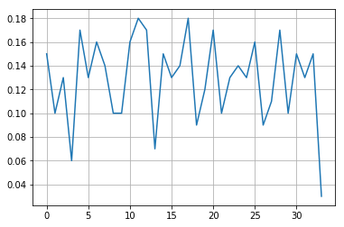

```python
# voted features means for cluster size 4
features_top_config.mean(axis=0).reset_index()[0].plot(grid=True)
```

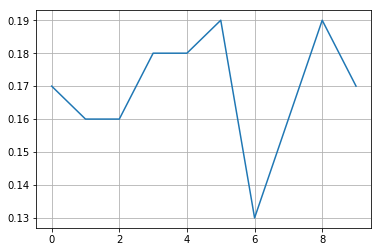

```python
# voted features means for cluster size 10
features_top_config.mean(axis=0).reset_index()[0].plot(grid=True)
```

### -> All voted configurations are closer to zero -> do nothing (?)

### 4. construct the configuration based on voting results - check the voting's preference ratios

-- no modification in this case

### 5. alter the original space based on the reconstructed configuration

```python
# select non-negations config as the best - take always first value from mem table
max_distances = dists.applymap(lambda dists: dists[0])
```

```python
from scipy.sparse.csgraph import minimum_spanning_tree

max_distances_inv = max_distances.applymap(lambda x: 1-x)
s_tree = minimum_spanning_tree(max_distances_inv).todense()
1 - s_tree[s_tree != 0]
```

```
matrix([[0.93887026, 0.93707481, 0.92818168, 0.9386318 , 0.93986618,
         0.93107124, 0.92408579, 0.92840611, 0.93808475, 0.92896719,
         0.94118472, 0.93913678, 0.93303503, 0.92943008, 0.93526532,
         0.94446704, 0.92769073, 0.9368644 , 0.94166164, 0.93432551,
         0.92958438, 0.95194344, 0.93495673, 0.93013143, 0.93114138,
         0.93348389, 0.93288073, 0.93469021, 0.9379024 , 0.93548975,
         0.93706078, 0.93715897, 0.93334362, 0.93299294, 0.93830918,
         0.93505492, 0.93073459, 0.94229286, 0.935097  , 0.9370187 ,
         0.92842014, 0.93013143, 0.95557644, 0.95606739, 0.94119875,
         0.94248923, 0.93770602, 0.92530614, 0.92950022, 0.93529338,
         0.93811281, 0.94160553, 0.92893914, 0.92973868, 0.93473229,
         0.93656983, 0.92704549, 0.94119875, 0.93028573, 0.93244589,
         0.93258616, 0.93676621, 0.94248923, 0.93309113, 0.93208119,
         0.94377972, 0.94069378, 0.92864457, 0.94417248, 0.93056627,
         0.93505492, 0.92714368, 0.92839208, 0.95035839, 0.93591056,
         0.93512505, 0.93627527, 0.93579835, 0.9337504 , 0.92924773,
         0.93607889, 0.93476035, 0.93578432, 0.936654  , 0.93617708,
         0.9305803 , 0.93621916, 0.93449384, 0.9401888 , 0.93152011,
         0.92728395, 0.93100111, 0.93052419, 0.9300613 , 0.93393275,
         0.926793  , 0.93593862, 0.93233367, 0.9316744 , 0.93095903,
         0.93091695, 0.93283865, 0.93163232, 0.92592333, 0.93334362,
         0.93135178, 0.93422732, 0.9384214 , 0.92794322, 0.93177259,
         0.93107124, 0.93439565, 0.93236173, 0.92857443, 0.93332959,
         0.9286586 , 0.93512505, 0.92867262, 0.93518116, 0.93281059,
         0.93555989, 0.92625998, 0.9279853 , 0.9300613 , 0.92844819,
         0.92958438, 0.93048211, 0.93139386, 0.93039795, 0.93975397,
         0.93036989, 0.93720105, 0.93502686, 0.93422732, 0.92832195,
         0.93344181, 0.92921968, 0.93708883, 0.93429746, 0.93373638,
         0.93208119, 0.93735535, 0.93401692, 0.93278254, 0.92903733,
         0.93311919, 0.93133776, 0.93296489, 0.93083278, 0.93415719,
         0.92889706, 0.93520921, 0.93948745, 0.93063641, 0.93053822,
         0.929907  , 0.92784503, 0.92853235, 0.93097305, 0.94140915,
         0.92815362, 0.93456397, 0.92972465, 0.92728395, 0.95428595,
         0.93111332, 0.92561473, 0.92945814, 0.93133776, 0.93311919,
         0.92757852, 0.92548849, 0.92593736, 0.93382054, 0.9260636 ,
         0.92728395, 0.93464813, 0.9358264 , 0.93116943, 0.93189884,
         0.94191413, 0.93126762, 0.92863054, 0.93534948, 0.93275449,
         0.93188481, 0.93447981, 0.93297892, 0.93244589, 0.9279853 ,
         0.93394678, 0.94004853, 0.93080473, 0.92634414, 0.92842014,
         0.92877081, 0.92910746, 0.93304905, 0.93335765, 0.92770476,
```

[output cut: 65 more lines]

```
         0.93887026, 0.9310993 , 0.935097  , 0.93254408, 0.9291776 ,
         0.93278254, 0.93149205, 0.92610568, 0.93574224, 0.94030102,
         0.93020157, 0.93533546, 0.93324543, 0.93445175, 0.93558794,
         0.92771879, 0.94003451, 0.9410164 , 0.93694856, 0.93140789,
         0.93055224, 0.93833724, 0.93811281, 0.93226354, 0.93586848,
         0.93612097, 0.93341375, 0.92968257, 0.93307711, 0.92806946,
         0.93715897, 0.93950148, 0.93968383, 0.93469021, 0.93342778,
         0.93880013, 0.93377846, 0.92558668, 0.93432551, 0.93504089,
         0.94067975, 0.92690522, 0.93526532, 0.93560197, 0.93069251,
         0.93728521, 0.93346986, 0.93519519, 0.93432551, 0.92992103,
         0.93962772, 0.9347884 , 0.93318932, 0.93062238, 0.94368153,
         0.92714368, 0.92825181, 0.93065043, 0.92719979, 0.93870194,
         0.93456397, 0.93711689, 0.93303503, 0.93348389, 0.93359611,
         0.93202508, 0.92955633, 0.93735535, 0.93502686, 0.92921968,
         0.93435356, 0.93443773, 0.9410164 , 0.93565808]])
```

```python
max_distances.index[np.argwhere(s_tree != 0)]
```

```
Int64Index([  [3, 144],   [4, 144],   [6, 144],   [7, 144],   [9, 144],
             [12, 144],  [13, 144],  [14, 144],  [15, 144],  [16, 144],
            ...
            [584, 144], [586, 144], [587, 144], [589, 144], [592, 144],
            [593, 144], [594, 144], [595, 144], [598, 144], [600, 144]],
           dtype='int64', length=599)
```

```python
import networkx as nx
import matplotlib.pyplot as plt
from pylab import rcParams

rcParams['figure.figsize'] = 14, 14

G = nx.DiGraph()
edge_labels = dict()
for x_i, y_i in np.argwhere(s_tree != 0):
    val = max_distances.iloc[x_i, y_i]
    G.add_edge(x_i, y_i, weight=round(val, 3))
    edge_labels[(x_i, y_i)] = round(val, 3)
```

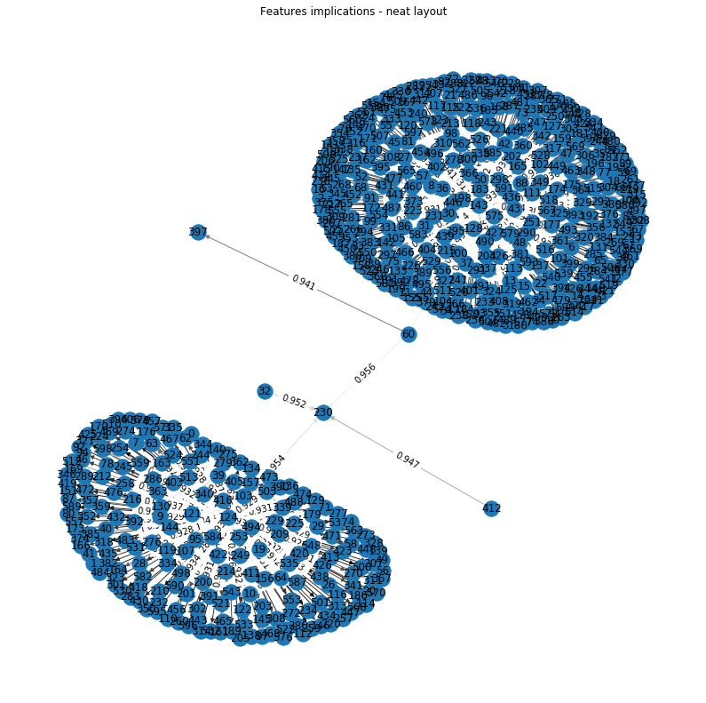

```python
plt.title('Features implications - neat layout')

pos = nx.drawing.nx_agraph.graphviz_layout(G, prog='neato')

nx.draw(G, pos, edge_color = [ i[2]['weight'] for i in G.edges(data=True) ], edge_cmap=plt.cm.gray,
        arrows=True, with_labels=True)
nx.draw_networkx_edge_labels(G, pos, edge_labels=edge_labels, label_pos=0.5)

pos = nx.get_node_attributes(G,'pos')
```

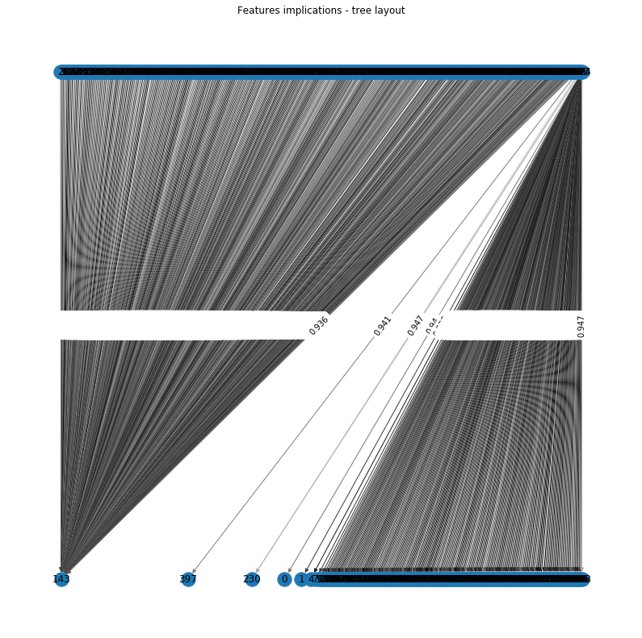

```python
plt.title('Features implications - tree layout')

pos = nx.drawing.nx_agraph.graphviz_layout(G, prog='dot')

nx.draw(G, pos, edge_color = [ i[2]['weight'] for i in G.edges(data=True) ], edge_cmap=plt.cm.gray,
        arrows=True, with_labels=True)
nx.draw_networkx_edge_labels(G, pos, edge_labels=edge_labels, label_pos=0.5)

pos = nx.get_node_attributes(G,'pos')
```